# Project 2nd attempt

Aashna

November 18, 2021

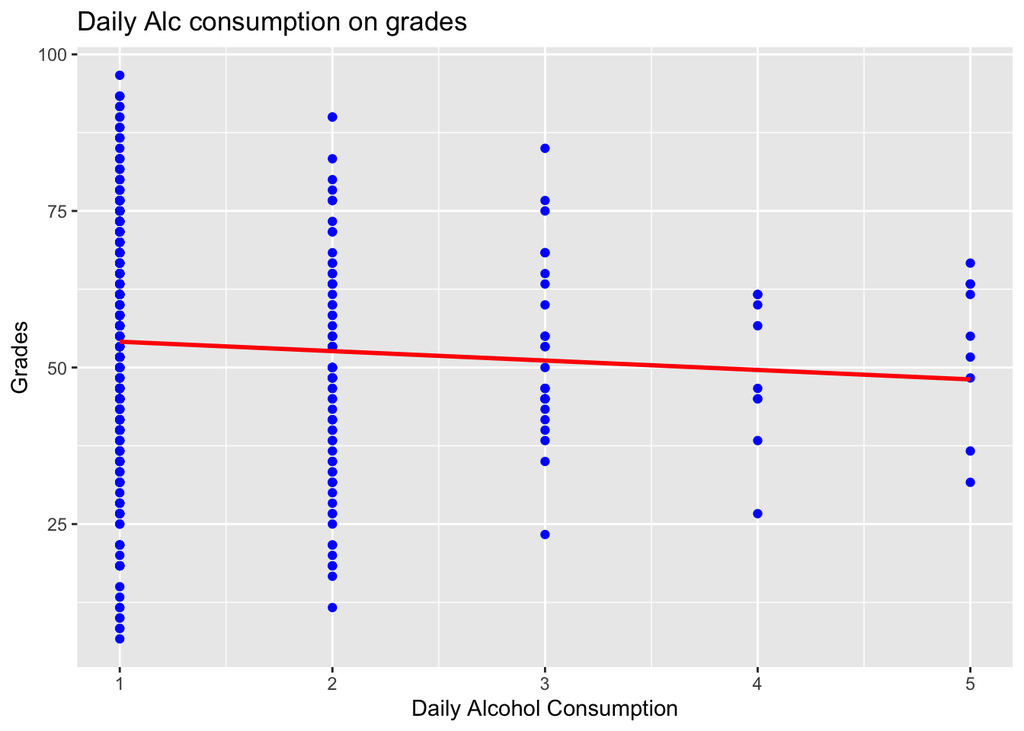

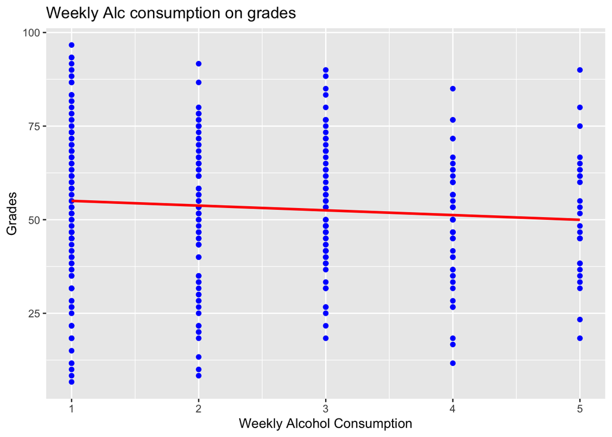

```
Grades against alcohol consumption
===============================================================================
                                        Dependent variable:
                    -----------------------------------------------------------
                                              Grades
                       (1)       (2)       (3)       (4)       (5)       (6)
-------------------------------------------------------------------------------
Dalc                 -1.505*   -1.510*   -1.580*  -1.634**   -1.141    -0.862
                     (0.832)   (0.827)   (0.811)   (0.799)   (0.806)   (0.835)

absences                        0.005     0.013    -0.011     0.003    -0.002
                               (0.092)   (0.095)   (0.095)   (0.095)   (0.093)

schoolsupyes                            -7.675*** -7.609*** -7.850*** -7.875***
                                         (1.891)   (1.885)   (1.981)   (1.970)

internetyes                                        5.177**   4.738*    4.180*
                                                   (2.418)   (2.431)   (2.378)

studytime                                                    2.722**   2.564**
                                                             (1.185)   (1.184)

traveltime                                                            -2.720**
                                                                       (1.288)

Constant            55.625*** 55.603*** 56.652*** 52.548*** 46.594*** 50.938***
                     (1.691)   (1.825)   (1.887)   (2.545)   (3.663)   (4.080)

-------------------------------------------------------------------------------
Observations           395       395       395       395       395       395
R2                    0.005     0.005     0.025     0.035     0.050     0.060
Adjusted R2           0.003    0.0002     0.017     0.026     0.038     0.046
Residual Std. Error  18.459    18.482    18.324    18.246    18.131    18.057
F Statistic           2.077     1.037    3.297**  3.588***  4.100***  4.142***
===============================================================================
Note:                                               *p<0.1; **p<0.05; ***p<0.01
```

Effect of alcohol consumption on grades:

We first run the regression model 1 with grades on daily alcohol consumption and see it is significant at 10% level. Since the model is a simple linear model, we suspect omitted variable bias and add other regressors to analyse the best baseline specification model.

As expected, we saw the fit of the model go up from 0.3% to 4.6% after adding other regressors.

We want to study if alcohol consumption affects the grades of a student. From the star table, we notice there’s a negative correlation but it is not statistically significant at standard confidence levels.

From the regression table, we see absence from school too does not have a significant effect on the grades. However, we notice the extra educational support has a very significant effect on grades with a 1% level. Having internet also positively affects the grades with a significance level of 10%. We noticed that study time positively affects the grades and is statistically significant at 5% whereas the travel time affects the grades negatively and is significant at 5% level.

Since alcohol consumption does not explain the variation in grades, we wanted to take a look at alternative specifications such as using nonlinear function on control variables and adding other regressors to see how the new variables affects the coefficient on the variable of interest.

*Alternatives Specifications*

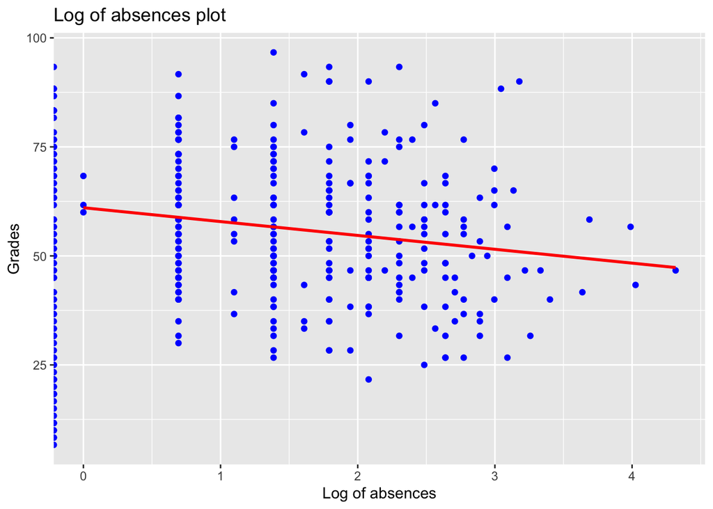

While running our regression tables, we notice that absences is not statistically significant and has tiny coefficient on grades which is abnormal. We draw a plot to see how absences distribute and found it is highly skewed, so we changed this control variable with a log that transforming a highly skewed variable into a more normalized data set. After putting it’s log format into the regression instead of using absences itself, we have a much better model. A 1% increase in absences is associated with 0.01*3.084 decreases in grades. Log format is statistically significant at 1% significant level and increases adjusted R2 to 0.112. More importantly, it changes the variable of interest to 10% confident level of statistically significant which means our baseline model suffers from upward bias that daily alcohol consumption is negative correlated with absences.

```
Additional regressors/nonlinearities on grades
=========================================================================
                                     Dependent variable:
                    -----------------------------------------------------
                                           Grades
                       (1)       (2)        (3)        (4)        (5)
-------------------------------------------------------------------------
Dalc                 -0.862    -1.405*    -1.835**   -1.817**   -2.729**
                     (0.835)   (0.771)    (0.807)    (0.811)    (1.160)

absences             -0.002
                     (0.093)

labsences                     -3.084***  -2.808***  -2.716***   -2.575**
                               (0.987)    (0.999)    (1.050)    (1.057)

schoolsupyes        -7.875*** -11.511*** -10.774*** -10.844*** -11.095***
                     (1.970)   (2.071)    (2.073)    (2.099)    (2.080)

internetyes          4.180*    4.754**    4.307**    4.420**    4.348**
                     (2.378)   (2.164)    (2.124)    (2.159)    (2.140)

studytime            2.564**    1.685      2.262*     2.285*     2.147*
                     (1.184)   (1.170)    (1.214)    (1.215)    (1.237)

traveltime          -2.720**    -1.196     -1.166     -1.139     -1.163
                     (1.288)   (1.201)    (1.197)    (1.203)    (1.192)

sexM                                      3.757**     3.721*     3.698*
                                          (1.911)    (1.915)    (1.914)

romanticyes                                           -0.744     -4.001
                                                     (1.910)    (3.253)

Dalc:romanticyes                                                 2.011
                                                                (1.507)

Constant            50.938*** 57.474***  55.042***  54.983***  56.629***
                     (4.080)   (3.809)    (3.927)    (3.937)    (4.410)

-------------------------------------------------------------------------
Observations           395       280        280        280        280
R2                    0.060     0.131      0.143      0.144      0.147
Adjusted R2           0.046     0.112      0.121      0.118      0.119
Residual Std. Error  18.057     14.590     14.513     14.536     14.531
F Statistic         4.142***   6.853***   6.493***   5.681***   5.185***
=========================================================================
Note:                                         *p<0.1; **p<0.05; ***p<0.01
```

```
Grades against romantic lives
=============================================================================
                                       Dependent variable:
                    ---------------------------------------------------------
                                             lgrade
                      (1)      (2)       (3)       (4)       (5)       (6)
-----------------------------------------------------------------------------
romanticyes         -0.101** -0.109** -0.107**   -0.094*   -0.096*   -0.086*
                    (0.049)  (0.049)   (0.049)   (0.050)   (0.050)   (0.048)

studytime                    0.078*** 0.073***  0.073***  0.074***  0.096***
                             (0.027)   (0.027)   (0.027)   (0.027)   (0.028)

goout                                 -0.059*** -0.055*** -0.058*** -0.062***
                                       (0.021)   (0.021)   (0.021)   (0.021)

age                                              -0.030*   -0.025    -0.023
                                                 (0.017)   (0.017)   (0.017)

addressU                                                   0.103**   0.109**
                                                           (0.052)   (0.052)

sexM                                                                0.121***
                                                                     (0.043)

Constant            3.933*** 3.776*** 3.969***  4.459***  4.297***  4.174***
                    (0.025)  (0.064)   (0.084)   (0.295)   (0.302)   (0.302)

-----------------------------------------------------------------------------
Observations          395      395       395       395       395       395
R2                   0.012    0.035     0.057     0.065     0.074     0.091
Adjusted R2          0.009    0.030     0.050     0.055     0.062     0.077
Residual Std. Error  0.435    0.430     0.426     0.425     0.423     0.420
F Statistic         4.755**  7.020*** 7.894***  6.740***  6.221***  6.483***
=============================================================================
Note:                                             *p<0.1; **p<0.05; ***p<0.01
```

In the above regressions, similar to the alcohol ones, we are looking at the grades of the same 395 students. We asked them about their relationship status, and created a dummy variable, where the variable takes a value of 1 if the student is in a romantic relationship, and 0 otherwise.

1. Studytime - weekly study time. We added this as students in relationships are likely to be spending less time studying, and it is an important variable in determining school grades.
2. Goout - How often does the student go out with friends, on a scale of 1-5. This variable likely affects the likelihood of a student being in a relationship, and also dictates how much attention the student is paying to their grades.
3. Student age, from 15-22. This variable was important in determining how interested a student would be to have a romantic life.
4. Address - a binary variable that takes value of 1 if the student lives in an urban environment, and 0 if the student lives in a rural home. We suspect that a student who lives in a rural area will be less likely to be in a romantic relationship.
5. Sex - a binary variable that takes value of 1 if the student is male. We were curious to see if a student’s sex affects their grades.

*Alternatives Specifications*

[figure not shown]

```
Additional regressors/nonlinearities on grades
===========================================================
                              Dependent variable:
                    ---------------------------------------
                     lgrade              Grades
                       (1)       (2)       (3)       (4)
-----------------------------------------------------------
romanticyes          -0.096*   -3.721*   -3.662*   -3.733*
                     (0.050)   (1.954)   (1.970)   (1.959)

studytime           0.074***  3.100***   2.893**   2.917**
                     (0.027)   (1.150)   (1.148)   (1.148)

goout               -0.058*** -2.664*** -2.380*** -2.362***
                     (0.021)   (0.892)   (0.854)   (0.856)

age                  -0.025    -1.207    -1.244*
                     (0.017)   (0.738)   (0.746)

lage                                               -0.036*
                                                   (0.022)

addressU             0.103**   4.758**   4.768**   4.793**
                     (0.052)   (2.206)   (2.235)   (2.220)

freetime                        1.226
                               (1.002)

famrel                                    0.470
                                         (1.075)

Constant            4.297***  69.103*** 71.344*** 62.443***
                     (0.302)  (13.105)  (13.382)   (7.089)

-----------------------------------------------------------
Observations           395       395       395       395
R2                    0.074     0.076     0.073     0.073
Adjusted R2           0.062     0.062     0.059     0.061
Residual Std. Error   0.423    17.900    17.933    17.915
F Statistic         6.221***  5.355***  5.094***  6.088***
===========================================================
Note:                           *p<0.1; **p<0.05; ***p<0.01
```